# TREC AutoJudge 2026

## TREC AutoJudge 2026

Pairwise preferences and citation evidence

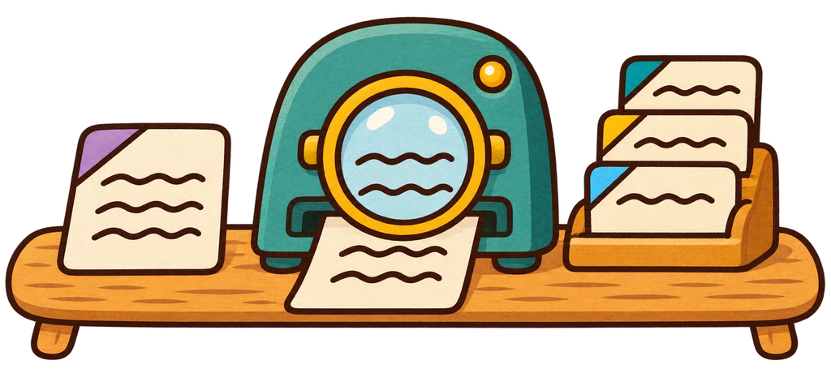

Nidhin Pattaniyil · Tanwir Zaman · Semih Yagli — NP Labs

## What we will walk through

1. The judging task
2. The four-day-workweek example
3. Pairwise preferences
4. Coverage and citation support
5. Organizer results

One example answer, followed from the judge’s input to its score.

## What AutoJudge predicts

RAG and RAGTIME · Three judging methods

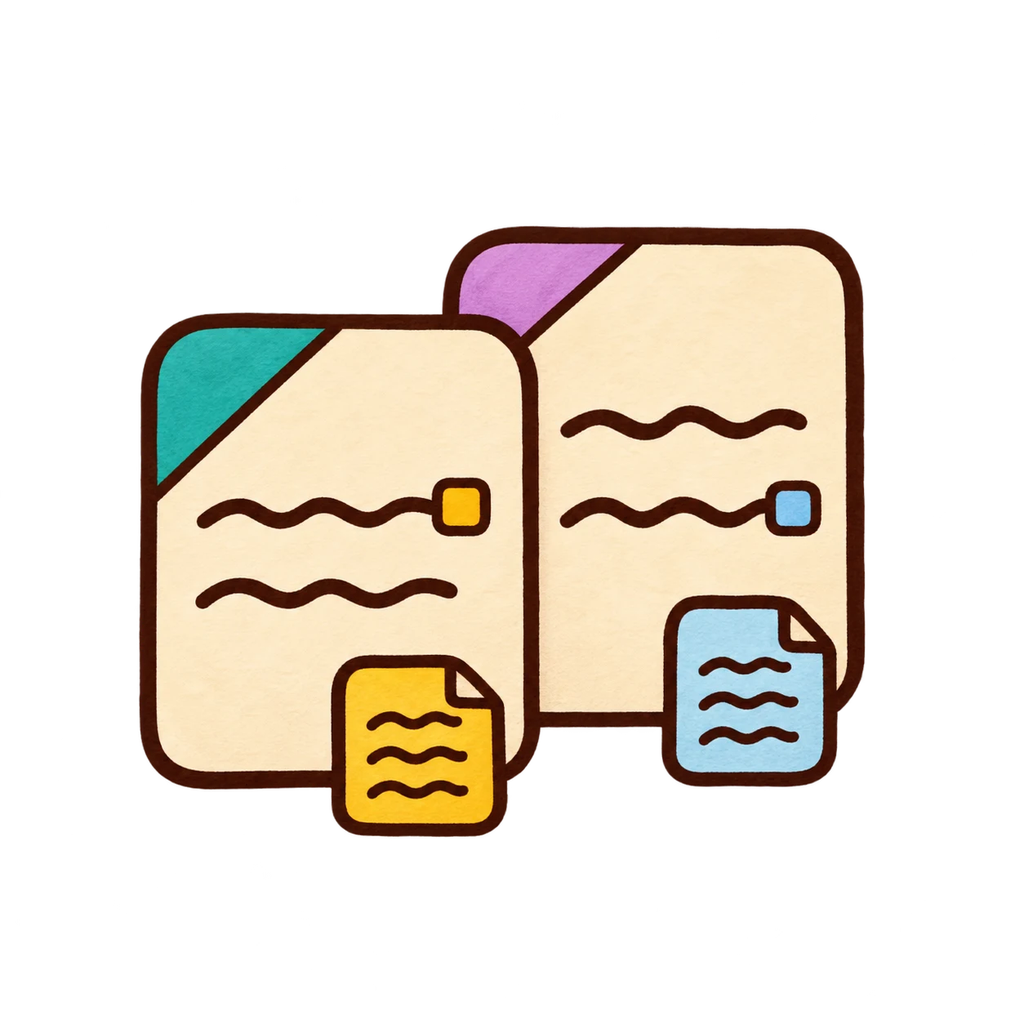

**Cited answers**

For each question, systems submit answers with citations.

→

[figure not shown]

**Score the answers**

Compare answers, score coverage and citation support, or average the two scores.

→

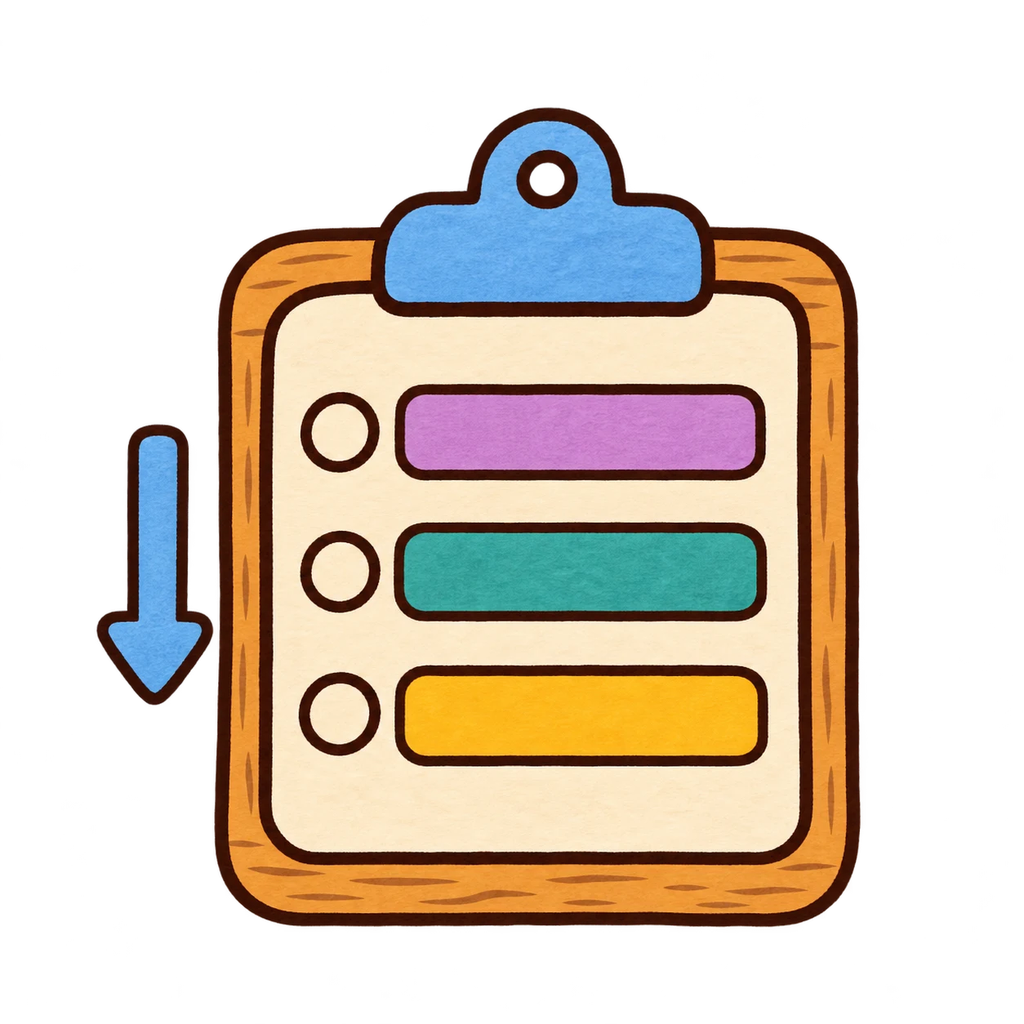

**Rank the systems**

Average each system’s scores across questions.

The organizers compare our predicted ranking with the official ranking of each host track.

## Three ways we judged answers

GPT-6 Luna · RAG and RAGTIME

### Pairwise

Compare two answers in both orders. Use the votes to score each answer.

### Evidence

Generate a reference answer and a checklist. Check what each answer covers and how well its citations support it.

### Combined

Average the two scores for each answer.

**50%**Pairwise

+

**50%**Evidence

We submitted each approach to both RAG and RAGTIME, for six runs.

## The answer we will follow

Illustrative example · Four-day workweek

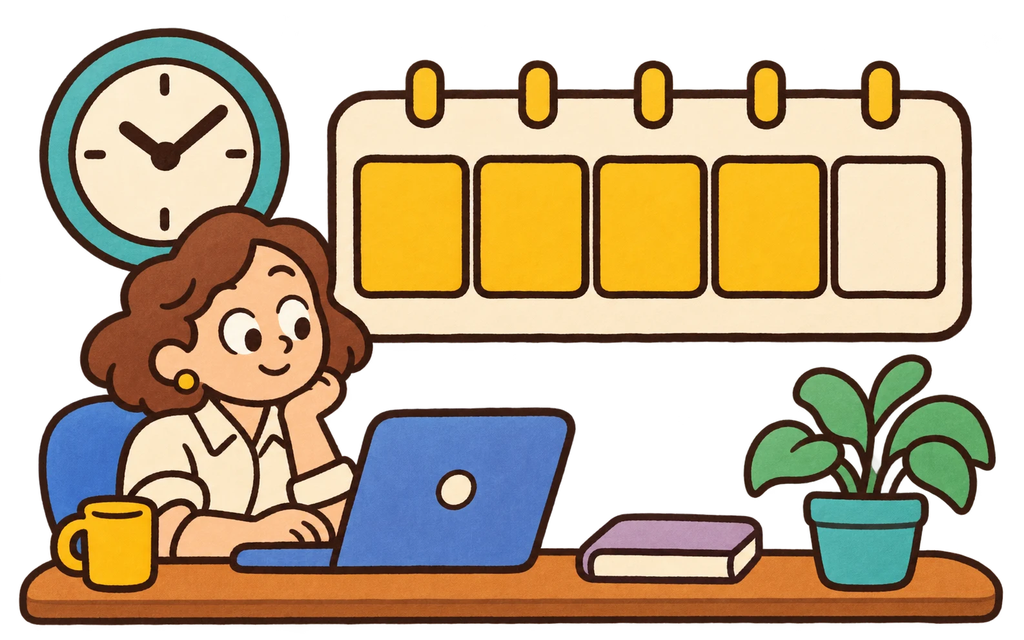

### Answer A

Employees work 32 hours a week [1]. This reduces stress and doubles company profits [2].

### Answer B

A four-day workweek gives employees more time off.

We’ll follow Answer A through preference, coverage and citation support.

## Pairwise preferences

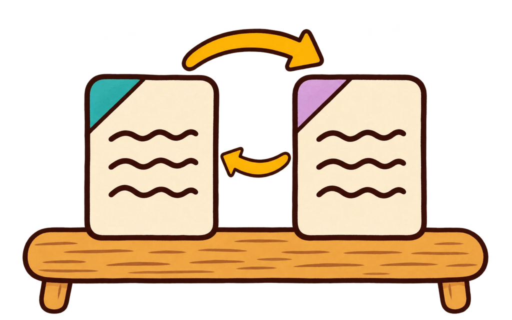

## Compare the two answers in both orders

Workweek example · Pairwise

### Input

- Question and length limit
- Two anonymous answers
- Citation markers

→

### GPT-6 Luna checks

- Answers the request
- Includes key information
- Handles facts carefully
- Stays relevant and clear

→

### Output

- First
- Second
- Tie

A short reason for the vote

| Order shown | Illustrative vote | Credit to A |
| --- | --- | --- |
| A, then B | First answer wins Covers hours and wellbeing. | 1 |
| B, then A | Tie | 0.5 |

A’s credit against B **0.75** (1 + 0.5) / 2

Swap positions to reduce order bias. Map each vote back to the original answers and average the credits (win 1, tie 0.5, loss 0).

## From pairwise judgments to a score

Workweek example · One question with 20 answers

Choose pairs **100 answer pairs**

Give each answer ten opponents. Count each pair once.

→

Vote in both orders **200 judgments**

Show each pair twice, swapping which answer comes first.

→

Turn votes into scores **Bradley–Terry**

Fit a rating for each answer and estimate its win chance against every opponent.

**Answer A scores 0.60.** We average its estimated win chances against the other 19 answers.

The full runs scheduled 98,770 ordered judgments on RAG and 50,470 on RAGTIME.

## Coverage and citation support

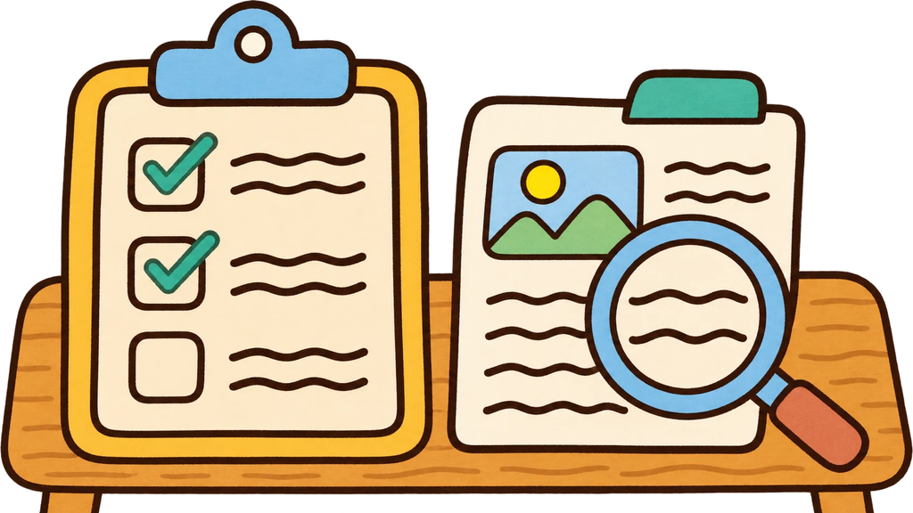

## GPT-6 Luna generates a reference answer and checklist

Workweek example · Two outputs from one request

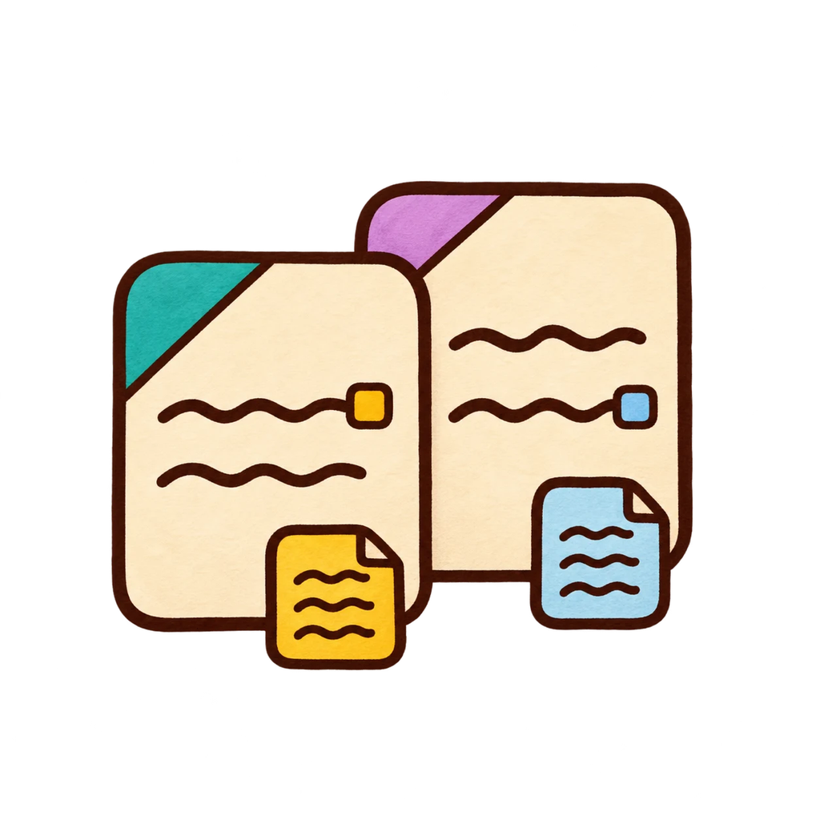

**Question + excerpts**

Pool cited evidence across answers.

→

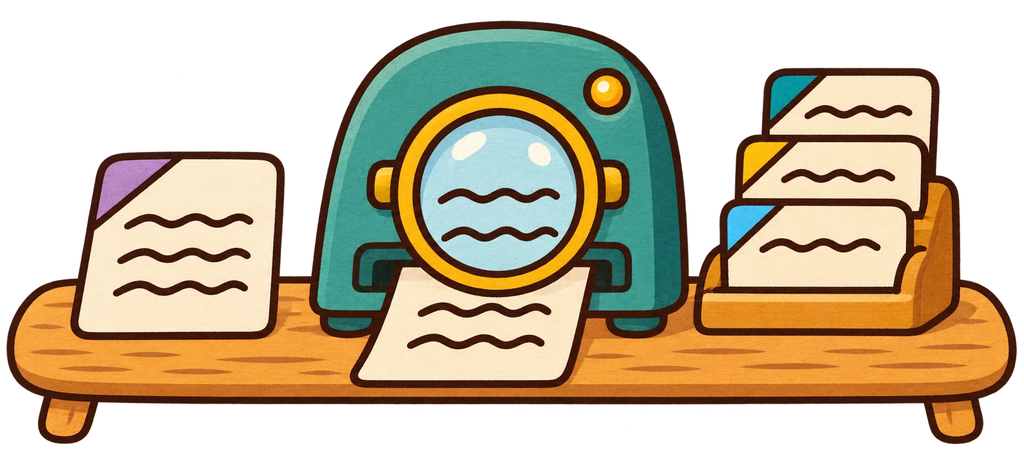

**GPT-6 Luna**

Distills the key points.

→

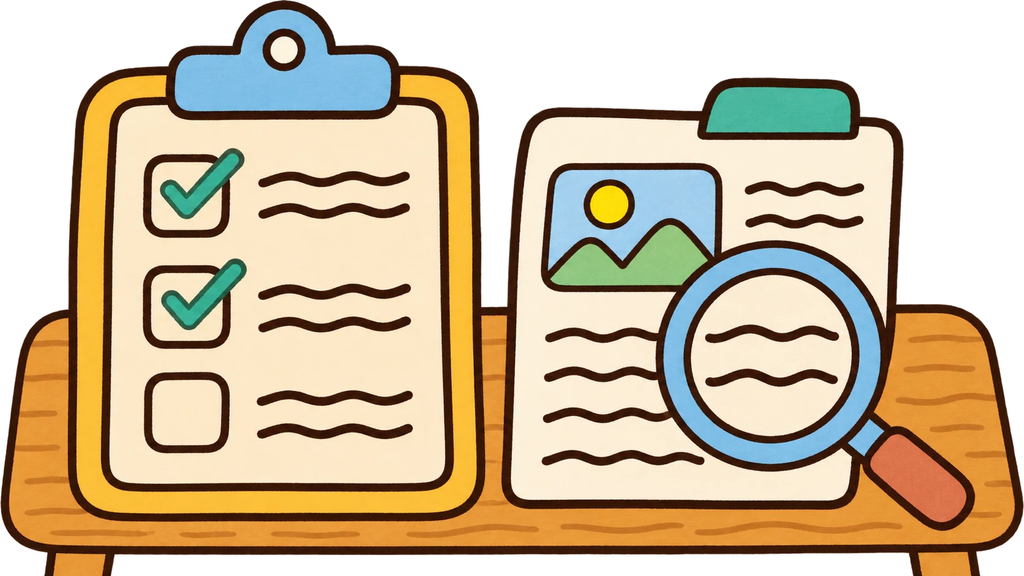

**Reference answer + checklist**

### Reference answer

**Saved with the run**

“Weekly hours can drop to 32 [1], and workers may report less stress [2].”

### Checklist used to grade each answer

| Required item | What earns credit |
| --- | --- |
| `I1` · Hours | Explains the change in weekly hours Example · Four eight-hour days (32 hours) |
| `I2` · Wellbeing | Describes a change in wellbeing Example · Reduced stress |

Illustrative outputs. RAG coverage averages the required factual and request items (such as format). Covered earns 1, partial 0.5, and missing 0. Optional items carry no weight.

## Judge coverage and citation support separately

Workweek example · Records for Answer A

### Coverage

**Input** Question + Answer A + frozen checklist

**Record** Each item’s grade and just the answer sentences that justify it.

| Item | Grade | Where in Answer A |
| --- | --- | --- |
| `I1`Working hours | Covered | `C1`“32 hours a week” |
| `I2`Wellbeing | Covered | `C2`“reduces stress” |

### Citation support

**Input** Answer A + its own cited sources

**Record** How well each citation supports its sentence, with the relevant excerpt.

| Pair | Supported portion | Credit |
| --- | --- | --- |
| `C1` [1] | 32 hours | 1 Full |
| `C2` [2] | **Less stress** Doubled profits unestablished. | 0.5 Partial |

**(1 + 0.5) / 2 = 0.75** for all three partial-credit citation measures here, with one citation per segment.

C1 and C2 label sentences in Answer A. Full credit can require several sentences. We use their labels to find the citation evidence.

## How Answer A earns its grade

Illustrative workweek example

### Answer A

Employees work 32 hours a week [1]. This reduces stress and doubles company profits [2].

| Required checklist item | Where Answer A covers it | Grade |
| --- | --- | --- |
| `I1` · Explain the change in weekly hours | “32 hours a week” | Covered · **1** |
| `I2` · Describe a change in wellbeing | “reduces stress” | Covered · **1** |

### Checklist coverage

(1 + 1) / 2 **= 1.00**

### Mean citation support

(1 + 0.5) / 2 **= 0.75**

Citation [1] earns **1** for fully supporting the hours sentence.

Citation [2] earns **0.5 for partial support** because it supports only the reduced stress claim. Doubled profits remain unverified.

## Results

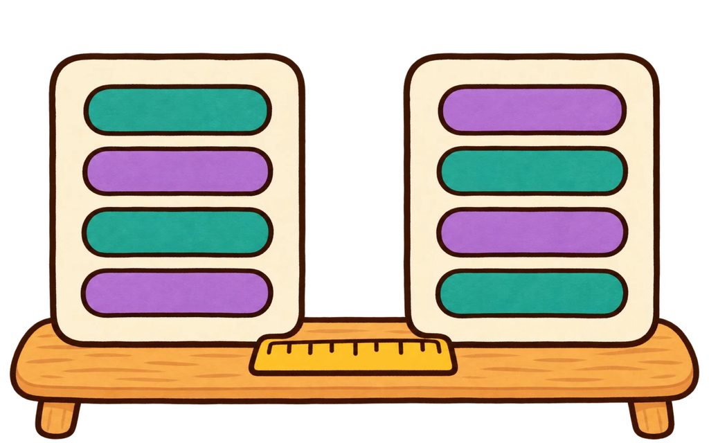

## Our best score on each track

Organizer results · Rank agreement (tauap_b)

### RAG

**0.573**

**Request coverage**

Ranked systems by how much of the request their answers covered.

### RAGTIME

**0.585**

**Full sentence support**

Ranked systems by how often the first citation fully supported an answer segment.

Top five overall on RAGTIME

We submitted answer scores for each rule. The organizer ranked systems using those scores and reported agreement with each track’s official ranking.

## How our three approaches scored

Organizer results · Rank agreement (tauap_b)

**We** scored answers in `ntp-combined-v1`. **The organizer** compared system rankings.

| Judging approach | RAG Human preferences | RAGTIME Mostly human F1 |
| --- | --- | --- |
| Pairwise | **0.506** | −0.010 |
| Evidence | 0.050 | **0.553** |
| Combined 50% Pairwise + 50% Evidence | 0.496 | 0.253 |

### Illustrative RAG example

Mean system scores across questions. Evidence averages coverage, citation precision, and recall.

| System | Rank by coverage only | Rank by Evidence |
| --- | --- | --- |
| A | **1st** · 0.90 | **2nd** · 0.65 (0.90 + 0.45 + 0.60) / 3 |
| B | **2nd** · 0.60 | **1st** · 0.75 (0.60 + 0.75 + 0.90) / 3 |

On RAG, request coverage scored 0.573 in rank agreement. Both citation checks scored below zero. [Organizer score tables](https://github.com/npatta01/trec-auto-judge-2026/blob/main/docs/organizer-results-2026-11-13.md)

## Conclusion

Three judging approaches and our best scores

1. **Pairwise** Compare answers head to head.
2. **Evidence** Check coverage and citation support.
3. **Combined** Give the two scores equal weight.

Our best rank agreement (tauap_b)

### RAG

**0.573** · Request coverage

### RAGTIME

**0.585** · Full sentence support

Top five overall

On both tracks, the best individual measure had higher agreement than the equal-weight blend.

[Notebook paper](https://github.com/npatta01/trec-auto-judge-2026/blob/986980322f1602442739db5fc318e3d6bf861c8d/docs/paper/autojudge2026.pdf) · [Organizer score tables](https://github.com/npatta01/trec-auto-judge-2026/blob/main/docs/organizer-results-2026-11-13.md)

## Appendix

Pairwise rating fit, worked scoring examples, and detailed results

## Select five neighbors on each side

Appendix · Pairwise comparison schedule

**Per question** Sort the answers by a fixed hash, then join the ends into a ring.

…−5−4−3−2−1**A**+1+2+3+4+5…

The ring shown unrolled. Numbers are offsets from A.

Example question**20 answers**

10 neighbors per answer

→

Count each pair once**100 unique pairs**

20 × 10 ÷ 2

→

Judge both orders**200 ordered judgments**

100 pairs × 2 orders

Use ten neighbors with at least eleven answers. Below eleven, compare every available pair.

## From pairwise votes to an answer score

Appendix · Workweek example · 20 answers

Judge 10 of A’s 19 pairs **A gets 0.75 against B**

A wins one presentation and ties the other. (1 + 0.5) / 2 = 0.75.

→

Fit Bradley–Terry **One rating per answer**

Fit the ratings to the credits from all 100 judged pairs for this question.

→

Predict every matchup **Rating gap → win chance**

Apply a logistic curve to A’s rating minus the opponent’s. A +1 gap gives a win chance of 0.73.

| A’s opponents | Example win chances | Mean |
| --- | --- | --- |
| 10 with direct votes | 5 at 0.65, 5 at 0.73 | **0.69** |
| 9 without direct votes | 4 at 0.40, 1 at 0.50, 4 at 0.60 | **0.50** |

A’s illustrative Pairwise score **0.60** (10 × 0.69 + 9 × 0.50) / 19

The same curve applies to every opponent. Equal ratings give a 0.50 win chance. The next slide gives the formula.

## How the Bradley–Terry rating fit works

Appendix · Pairwise rating fit

Observe**A earns 0.75 vs B**

One of the pairs we judged

→

Fit Bradley–Terry**One rating per answer**

Fit ratings jointly to match observed credits. The L2 penalty limits extreme ratings.

→

Predict**A’s win chance vs each opponent**

Use the ratings for pairs with no direct vote, too.

| A’s 19 opponents | Mean fitted win chance |
| --- | --- |
| 10 compared with A | 0.69 |
| 9 with no direct vote | 0.50 |

A’s illustrative Pairwise score **0.60** (10 × 0.69 + 9 × 0.50) / 19

**Fit details** Minimize logistic loss with an L2 penalty. P(A beats B) = σ(s<sub>A</sub> − s<sub>B</sub>), where σ is the logistic function. A one-point rating gap gives a win chance of about 0.73. With every pair judged, average the observed credits directly.

## What the RAG and RAGTIME metrics measure

Appendix · Host-track criteria and our Evidence measures

### RAG

**Official criteria** A nugget rubric for each request, plus weighted citation precision and recall.

| Our proxy | What it checks |
| --- | --- |
| Request coverage | Does the answer meet the request? |
| Citation precision | Do the supplied citations support their segments? |
| Citation recall | How much of the answer has citation support? |

### RAGTIME

**Official criteria** Correctly cited nuggets and citation precision on eligible report sentences. The main measure uses the top-priority citation.

| Our proxy | What it checks |
| --- | --- |
| Grounded factual coverage | Are the requested facts present and supported by their own citations? |
| Top-citation support | Does the system’s first-choice citation support each segment? |

**Nuggets** Key facts or requirements that an answer or report should cover.

[RAG official guidelines](https://github.com/TREC-RAG/trec-rag-skills/blob/main/skills/trec-rag-2026-track-guidelines/references/rag-task.md#evaluation) · [RAGTIME official guidelines](https://docs.google.com/document/d/1XqypNTHxIdazxfnUebrp-EsUuGNhodhQGrJIDnYGaB4/edit?usp=sharing)

## Two citations can produce three different scores

Appendix · Illustrative example · One segment, two citations

### First citation

Unestablished **0**

### Second citation

Full support **1**

| Measure | How credit is aggregated | Example |
| --- | --- | --- |
| RAG precision | Mean credit across every segment–citation pair | (0 + 1) / 2 **= 0.50** |
| RAG recall | Best single citation per segment, then mean | max(0, 1) **= 1** |
| RAGTIME support | First citation in the system’s order per segment, then mean | first(0, 1) **= 0** |

**Why best or first** We label each citation on its own, so our RAG recall proxy takes the strongest label. RAGTIME uses the system’s first choice.

Support credit is full 1 · partial 0.5 · unestablished 0. Uncited segments contribute zero to RAG recall and RAGTIME top-citation support.

## Join the records by answer segment

Appendix · Workweek example

Coverage link**I2 → C2**

Wellbeing through reduced stress

C2 also claims doubled profits.

→

Check the excerpt**C2 + [2]**

“Workers reported less stress.”

Illustrative retained excerpt

→

Grounded item**I2 earns 1**

Reduced stress satisfies wellbeing.

C2 keeps its 0.5 citation credit.

| Measure | Why both items count | Credit |
| --- | --- | --- |
| RAG coverage | A addresses both required items. | **2/2** |
| RAGTIME grounded factual coverage | [1] supports hours. [2] supports reduced stress. | **2/2** |

For unresolved factual items, check the linked segments’ retained excerpts when available. Partial grounding can earn 0.5 in RAGTIME Evidence.

## Score coverage and citations, then combine

Appendix · Workweek example · Answer A

**Pairwise = 0.60** Illustrative fitted mean for Answer A

### RAG

Request coverage **1.00**

Citation precision **0.75**

Citation recall **0.75**

**Evidence**  
(1 + 0.75 + 0.75) / 3 **≈ 0.833**

**Combined**  
(0.60 + 0.833…) / 2 **≈ 0.717**

### RAGTIME

Grounded factual coverage **1.00**

Top-citation support **0.75**

**Evidence**  
(1 + 0.75) / 2 **= 0.875**

**Combined**  
(0.60 + 0.875) / 2 **≈ 0.738**

**Combined = ½ Pairwise + ½ Evidence**

Score each answer first. The system score is the mean across its questions.

## What the organizers measured

Appendix · Organizer evaluation · November 13, 2026

Select**Manually annotated topics**

→

Aggregate**Mean judge score per system**

→

Compare**Official leaderboard ranks**

| Stage | RAG | RAGTIME |
| --- | --- | --- |
| Judged inputs | 119 questions · 83 systems | 103 questions · 49 systems |
| Meta-evaluation | 42 annotated topics · 41 systems | 17 annotated topics · 27 systems |
| Official target | `bt_score`Bradley–Terry rating from human side-by-side preferences | `f1_llmfilled`F1 from the mostly human assessment |

**Missing score** Assign 0 to any official system without a judge score before comparing ranks.

`tauap_b` is tie-aware AP rank correlation. It gives more weight to disagreements near the top. A value of 1 means full agreement.

## RAG rank agreement by scoring rule

Appendix · 10 rankings · Human preference ranking · tauap_b

**We** scored the answers for each rule. **The organizer** compared the resulting system ranking with the official one.

| Our scoring rule | Organizer score |
| --- | --- |
| Request coverage alone | **0.573318** |
| Pairwise votes | 0.505701 |
| Combined (Pairwise + Evidence) | 0.496304 |
| Grounded factual coverage (partial credit) | 0.433537 |
| Evidence composite | 0.050418 |
| Grounded checklist recall (full credit only) | 0.009977 |
| Citation recall (partial credit) | −0.169184 |
| Citation precision (partial credit) | −0.192315 |
| Citation recall (full credit only, unweighted) | −0.201422 |
| Citation precision (full credit only, unweighted) | −0.202130 |

Our `ntp-combined-v1` run reported these rankings. Standalone Pairwise also scored 0.505701. [Organizer score table](https://github.com/npatta01/trec-auto-judge-2026/blob/main/docs/organizer-results/2026-11-13/rag26-scores.tsv)

## RAGTIME rank agreement by scoring rule

Appendix · 7 rankings · Official F1 from mostly human assessments · tauap_b

**We** scored the answers for each rule. **The organizer** compared the resulting system ranking with the official one.

| Our scoring rule | Organizer score |
| --- | --- |
| Sentence support from the first citation (full credit only) | **0.584562** |
| Sentence support from the first citation (partial credit) | 0.558222 |
| Evidence composite | 0.553361 |
| Grounded nugget recall estimate (full credit only) | 0.539442 |
| Grounded factual coverage (partial credit) | 0.379872 |
| Combined (Pairwise + Evidence) | 0.252738 |
| Pairwise votes | −0.009917 |

**Full credit only** We count the fraction of an answer’s segments fully supported by their first citation.

Our `ntp-combined-v1` run reported these rankings. Standalone Pairwise also scored −0.009917. [Organizer score table](https://github.com/npatta01/trec-auto-judge-2026/blob/main/docs/organizer-results/2026-11-13/ragtime26-scores.tsv)

## Detailed scores by judging measure

Appendix · Organizer results

### RAG

1. Request coverage**0.573318**
2. Pairwise**0.505701**
3. Combined average**0.496304**
4. Coverage and citation score**0.050418**

−0.100.30.6

### RAGTIME Top five overall

1. Sentence support (full-only)**0.584562**
2. Coverage and citation score**0.553361**
3. Combined average**0.252738**
4. Pairwise**−0.009917**

−0.100.30.6

Each row is our `tauap_b` rank agreement for the named judging measure. Each run tag is represented by its best measure. Full-only sentence support put `ntp-combined-v1` in the RAGTIME top five.

## Scoring rules and edge cases

Appendix · Evidence

| Case | Treatment in the Evidence score |
| --- | --- |
| Pooled excerpts exceed the input budget | Build the checklist from deduplicated, validated claims. Keep source links and qualifications. |
| Several partially supporting citations | Use the best single citation for RAG recall. Several 0.5 citations still yield 0.5 for the segment. |
| Explicit non-claim | Exclude from partial-credit citation measures. Retain segments without an explicit non-claim label. |
| Empty citation denominator | Return 0. Record the denominator count in the audit. |

Coverage depends on which requirements the generated checklist includes. Citation grades depend on the supplied excerpts.

## Runs submitted to TIRA

Appendix · Reproducibility

All six runs use `openai/gpt-6-luna`.

| Method | RAG · TIRA data ID | RAGTIME · TIRA data ID |
| --- | --- | --- |
| Pairwise | `ntp-rag-pairwise-10-v1` 2459 | `ntp-ragtime-pairwise-10-v1` 2480 |
| Evidence | `ntp-rag-evidence-v1` 2521 | `ntp-ragtime-evidence-v1` 2523 |
| Combined | `ntp-rag-combined-v1` 2522 | `ntp-ragtime-combined-v1` 2524 |

[Notebook paper and frozen revisions](https://github.com/npatta01/trec-auto-judge-2026/blob/986980322f1602442739db5fc318e3d6bf861c8d/docs/paper/autojudge2026.pdf) · [Organizer README and scores](https://github.com/npatta01/trec-auto-judge-2026/tree/main/docs/organizer-results/2026-11-13)